# Relatório 03 - Estatística Descritiva

Leonardo Lois Rodrigues

03/10/2024

# 1 - Objetivo:

Descrever sobre teoria de conjuntos, exemplos e aplicações.

Diante do objetivo do relatório, apresentaremos nas próximas subseções os pontos a serem discutidos:

# 2 - Teoria de conjuntos:

## 2.1 - Experimento Aleatório;

A cada experimento aleatório está associado o resultado obtido, que não é previsível, chamado evento aleatório.

Exemplos:

1. lançamento de uma moeda honesta;
2. lançamento de um dado;

No exemplo a os eventos associados são cara (C) e coroa (K);

No exemplo b poderá ocorrer uma das faces 1, 2, 3, 4, 5 ou 6.

## 2.2 - População ou conjunto:

População: é o conjunto formado por indivíduos ou objetos que têm pelo menos uma variável comum e observável. Podemos falar em:

• população dos alunos do primeiro período de uma faculdade;

• população dos operários da indústria automobilística;

• população de alturas em cm das pessoas de determinado bairro;

• população de peças fabricadas numa linha de produção, e assim por diante.

## 2.3 - Espaço Amostral

Espaço amostral de um experimento aleatório é o conjunto dos resultados do experimento. Os elementos do espaço amostral serão chamados também de pontos amostrais. Representaremos o espaço amostral por Ω.

Exemplos:

1. lançamento de uma moeda honesta;

Ω = {C, k}

2. lançamento de um dado;

Ω ={l, 2, 3, 4, 5, 6}

3. lançamento de duas moedas;

Ω ={(C, C), (C, K), (K, C), (K, K)}

4. determinação da vida útil de um componente eletrônico.

Ω = {t ∈ IR; t ≥ O}

5. Detenninação do espaço an1ostral: podemos determiná-lo por uma tabela de dupla entrada (produto ca1tesiano ).

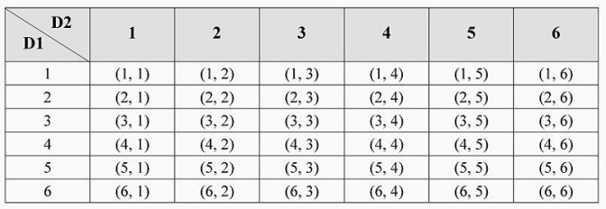

Figura 1

## 2.4 - Evento

O evento aleatório pode ser um único ponto amostral ou uma reunião deles, como veremos no exemplo a seguir:

Lançam - se dois dados. Enumerar os seguintes eventos:

A: saída de faces iguais;

B: saída de faces cuja soma seja igual a 10;

C: saída de faces cuja son1a seja menor que 2;

D: saída de faces cuja soma seja menor que 15;

E: saída de faces onde uma face é o dobro da outra.

Os eventos pedidos são:

A = {(1, 1), (2, 2), (3, 3), (4, 4), (5, 5), (6, 6)}

B = {(4, 6), (5, 5), (6, 4)}

C = ∅ (evento impossível)

D = Ω (evento certo)

E= {(l, 2), (2, 1), (2, 4), (3, 6), (4, 2), (6, 3)}

Uma outra maneira de determinar o espaço amostral desse experimento é usar o diagrama ern árvore:

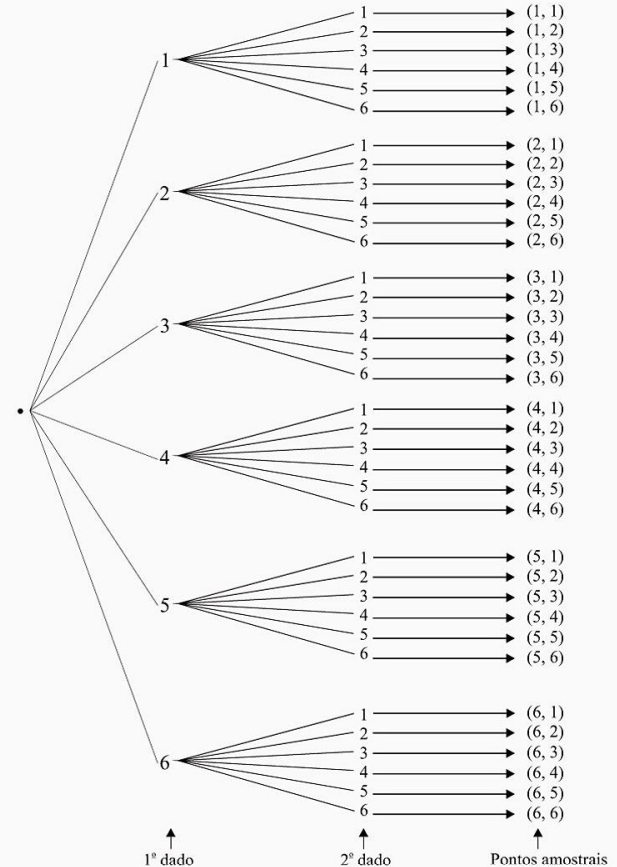

Figura 2

## 2.5 - Operações

Sejam A e B dois eventos de F(Ω). As seguintes operações são definidas:

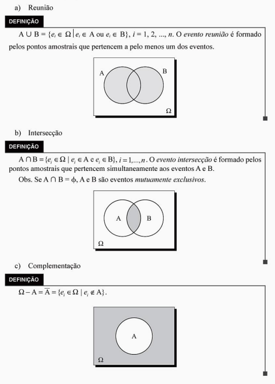

Figura 3

# 3 - Probabilidade:

## 3.1 - Definição

É a função P que associa a cada evento de F um número real pertencente ao intervalo [O, 1], satisfazendo os axiomas:

1. $P(\Omega) = 1$
2. $P(A \cup B) = P(A) + P(B)$, se $A$ e $B$ forem mutuamente exclusivos.
3. $P\left( \bigcup_{i=1}^{n} A_i \right) = \sum_{i=1}^{n} P(A_i)$, se $A_1, A_2, \dots, A_n$ forem, dois a dois, eventos mutuamente exclusivos.

Observamos pela definição que $0 \leq P(A) \leq 1$ para todo evento $A$, $A \subseteq \Omega$.

Apartir daqui vamos dar enfase aos exemplos:

## 3.2 - Probabilidade condicional

Introduziremos a noção de probabilidade condicional através do seguinte exemplo:

Exemplo 1

$$P(Q / M) = \frac{80}{150} \quad \text{(probabilidade de que o aluno curse química, condicionado ao fato de ser mulher).}$$

Observamos, porém, que $P(M \cap Q) = \frac{80}{250}$ e $P(M) = \frac{150}{250}$. Para obtermos o resultado do problema, basta considerar que:

$$P(Q / M) = \frac{80}{150} = \frac{250}{150} \cdot \frac{80}{250}$$

Logo:

$$P(Q / M) = \frac{P(M \cap Q)}{P(M)}$$

Sejam $A \subseteq \Omega$ e $B \subseteq \Omega$. Definimos a $(A / B)$ como segue:

$$P(A / B) = \frac{P(A \cap B)}{P(B)}, \quad \text{se } P(B) \neq 0$$

Também:

$$P(B / A) = \frac{P(B \cap A)}{P(A)}, \quad \text{se } P(A) \neq 0$$

## 3.3 - Teorema de Bayes

### 3.3.1 - Teorema da probabilidade total

Sejam $A_1, A_2, \dots, A_n$ eventos que formam uma partição do espaço amostral. Seja $B$ um evento desse espaço. Então, temos:

$$P(B) = \sum_{i=1}^{n} P(A_i) \cdot P(B \mid A_i)$$

Exemplo 2

Uma urna contém 3 bolas brancas e 2 amarelas. Uma segunda urna contém 4 bolas brancas e 2 amarelas. Escolhe-se, ao acaso, uma urna e dela retira-se, também ao acaso, uma bola. Qual a probabilidade de que seja branca?

Resolução:

P(B) = P(B | I) + P(B | II)

$$P(B) = P(I) \cdot P(B | I) + P(II) \cdot P(B | II)$$

Calculando,

$$P(B | I) = \frac{3}{5}, \quad P(B | II) = \frac{4}{6}$$

Portanto,

$$P(B) = \frac{1}{2} \cdot \frac{3}{5} + \frac{1}{2} \cdot \frac{4}{6}$$

Sejam A_1, A_2, , A_n eventos que formam uma partição do espaço. Seja B um evento. Sejam conhecidas P(A_i) e P(B | A_i) , para i = 1, 2, , n . Então:

$$P(A_i | B) = \frac{P(A_i) \cdot P(B | A_i)}{\sum_{j=1}^{n} P(A_j) \cdot P(B | A_j)}.$$

### 3.3.2 - O teorema de Bayes

É também chamado de teorema da probabilidade a posteriori. Ele relaciona uma das parcelas da probabilidade total com a própria probabilidade total.

Exemplo 3

A urna A contém 3 fichas vermelhas e 2 azuis, e a urna B contém 2 vermelhas e 8 azuis. Joga-se uma moeda “honesta”. Se a moeda der cara, extrai-se uma ficha da urna A; se der coroa, extrai-se uma ficha da urna B. Uma ficha vermelha é extraída. Qual a probabilidade de ter saído cara no lançamento?

Resolução:

Queremos: P(C | V)

Utilizando a fórmula da probabilidade total:

$$P(V) = P(C) \cdot P(V | C) + P(K) \cdot P(V | K).$$

Calculando,

$$P(V) = \frac{1}{2} \cdot \frac{3}{5} + \frac{1}{2} \cdot \frac{2}{10} = \frac{3}{10} + \frac{1}{10} = \frac{4}{10}.$$

Responda as seguintes questões a seguir, relacionadas a probabilidade:

Exemplo 4:

- Sabe-se que cada uma das pessoas A, B, C e D, falam a verdade uma dado instante com probabilidade de 1/3. Suponha que A faça uma afirmação, e D disse que C, que disse que B, que disse que A estava falando a verdade. Qual a probabilidade de que A tenha falado a verdade?

Resolução

Tudo começa com a pessoa D dizendo que as pessoas C, B e A falaram a verdade. Portanto, vamos calcular a probabilidade condicional de que a pessoa A falou a verdade na certeza que D disse a verdade, assim:

$$P(A|D) = \frac{P(A \cap D)}{P(D)}$$
onde:

1. $$P(A \cap D) = \frac{1}{81} + \frac{4}{81} + \frac{4}{81} + \frac{4}{81} = \frac{13}{81}$$

$$P(D) = \frac{1}{81} + 6\cdot \frac{4}{81} + \frac{16}{81} = \frac{41}{81}$$

(Faça o diagrama de árvore, para simplificar o entendimento)

As probabilidades (1) e (2) são encontradas pelo diagrama de árvore, daí:

$$P(A\cap D) = \frac{13}{81} \cdot \frac{81}{41} = \frac{13}{41} \approx 31,7\%$$

Resolução

Queremos encontrar a probabilidade condicional de que o progenitor seja AA dado que o descendente seja Aa.

Teorema de Bayes

$$P(\text{AA}|\text{Aa}) = \frac{P(\text{Aa}|\text{AA}) \cdot P(\text{AA})}{P(\text{Aa})}$$

Como o progenitor é AA ou Aa. Assim, temos que:

$$P(\text{AA}) = P(\text{Aa}) = \frac{1}{2}$$

Agora, podemos calcular $P(\text{Aa})$ da seguinte forma:

$$P(\text{Aa}) = P(\text{Aa}|\text{AA}) \cdot P(\text{AA}) + P(\text{Aa}|\text{Aa}) \cdot P(\text{Aa})$$

onde:

$$P(\text{Aa}|\text{AA}) = 1 \quad \text{e} \quad P(\text{Aa}|\text{Aa}) = \frac{1}{2}$$

2.3) Dado que $B = \bigcup_{j=1}^{n} B_j$, com $B_1, B_2, \dots, B_n$ mutuamente disjuntos, e que $P(A | B_j) = p$ para todo $j = 1, 2, \dots, n$, vamos demonstrar que $P(A | B) = p$.

Passo 1: Teorema da probabilidade total

Sabemos que:
$$P(A | B) = \frac{P(A \cap B)}{P(B)}$$
Onde $B = \bigcup_{j=1}^{n} B_j$, ou seja, $B$ é a união dos eventos mutuamente disjuntos $B_1, B_2, \dots, B_n$. Logo, podemos escrever:
$$P(A \cap B) = P\left( A \cap \bigcup_{j=1}^{n} B_j \right)$$
Como os eventos $B_j$ são mutuamente disjuntos, isso implica que:
$$P(A \cap B) = \sum_{j=1}^{n} P(A \cap B_j)$$

Passo 2: Aplicando a definição de probabilidade condicional

Sabemos que $P(A \cap B_j) = P(A | B_j) \cdot P(B_j)$. Substituindo na equação anterior:
$$P(A \cap B) = \sum_{j=1}^{n} P(A | B_j) \cdot P(B_j)$$

Passo 3: Substituindo $P(A | B_j) = p$

Pelo enunciado, sabemos que $P(A | B_j) = p$ para todo $j$. Portanto, a equação fica:
$$P(A \cap B) = \sum_{j=1}^{n} p \cdot P(B_j)$$
Fatorando $p$ da soma:
$$P(A \cap B) = p \cdot \sum_{j=1}^{n} P(B_j)$$

Passo 4: Usando a probabilidade total de $B$

Sabemos que $\sum_{j=1}^{n} P(B_j) = P\left( \bigcup_{j=1}^{n} B_j \right) = P(B)$. Assim, temos:
$$P(A \cap B) = p \cdot P(B)$$

Passo 5: Substituindo na fórmula original de $P(A | B)$

Agora, podemos substituir $P(A \cap B) = p \cdot P(B)$ na fórmula de $P(A | B)$:
$$P(A | B) = \frac{P(A \cap B)}{P(B)} = \frac{p \cdot P(B)}{P(B)} = p$$

Portanto, mostramos que $P(A | B) = p$.

# 4 - Referências Bibliográficas:

Morettin, Luiz Gonzaga Estatística básica : probabilidade e inferência, volume único I Luiz Gonzaga Morettin. – São Paulo : Pearson Prentice Hall, 201 O.